# ECOINFORMÁTICA: Reto final - Producto 2

Beatriz Pérez Cazorla

# **Caracterización de poblaciones de robledal en función de variables biofísicas**

# **Resumen**

En este producto realizaremos una clasificación de los distintos subtipos o poblaciones de ecosistemas teniendo en cuenta variables climáticas, edáficas y de funcionamiento ecosistémico. El producto final será un mapa o una tabla que muestre a qué grupo pertenece cada píxel del mapa de distribución del robledal en Sierra Nevada. Es decir, se indicarán los distintos “tipos” de robledal en función de las variables biofísicas utilizadas en la clasificación.

# **Introducción**

En Sierra Nevada se han realizado numerosos estudios en los que se han analizado de forma puntual diferentes aspectos de la ecología de *Quercus pyrenaica* : análisis de los factores abióticos que afectan al establecimiento de semillas (Baraza et al. 2004); utilización de plantas nodrizas para la restauración de robledales (Castro et al. 2006); estudios de reclutamiento de juveniles bajo diferentes tratamientos de contenido hídrico (Mendoza et al. 2009); efectos de la herviboría (Baraza et al. 2010); efectos de la heterogeneidad ambiental generada por plantas nodriza sobre el crecimiento y la supervivencia de *Q. pyrenaica* (Gómez-Aparicio et al. 2005), etc. Todos estos estudios se refieren a aspectos concretos ecológicos y se han llevado a cabo en algunas poblaciones de los robledales de Sierra Nevada, y aunque aportan un gran conocimiento en detalle de la ecología de esta especie, no analizan las diferencias entre las diferentes poblaciones de Sierra Nevada.

Nuestro objetivo será clasificar los distintos subtipos o poblaciones de roble mejolo (*Quercus pyrenaica*) teniendo en cuenta variables climáticas, edáficas y de funcionamiento ecosistémico, cuyos resultados tendrán imporantes implicaciones en la gestión y conservación de estos frágiles ecosistemas.

# **Material y métodos**

**Base de datos utilizadas**

Hemos utilizado un conjunto de variables que se pueden agrupar en función del grupo temático del que informan: topográficas, hidrográficas, climáticas, de distancia e influencia antrópica

**Análisis de clasificación cluster**

Para realizar la clasificación utilizaremos el análisis cluster. El análisis cluster es un conjunto de técnicas multivariantes utilizadas para clasificar a un conjunto de individuos en grupos homogéneos. El agrupamiento se basa en la idea de distancia o similitud en las observaciones.El objetivo, por tanto, es obtener clasificaciones (clusterings). Este método posee una extraordinaria importancia en la investigación científica, dado que la clasificación es uno de los objetivos fundamentales de la ciencia. El uso de esta variable sintética hace más fácil la interpretación de los patrones espaciales(Alcaraz-Segura et al.,2006) de las poblaciones de roble. El agrupamiento se lleva a cabo a través de el algoritmo de clasificación K-medias, que permite asignar a cada observación el cluster que se encuentra más próximo en términos del centroide (media), método utilizado en la minería de datos.

A través de este análisis podemos determinar el comportamiento similiar de los diferentes núcleos existentes en Sierra Nevada en función de las diferentes variables ambientales.

Los análisis se realizarán con el software estadístico R version 3.0.2. Con el que llevaremos a cabo el siguiente procedimiento:

En primer lugar, instalamos y cargamos los paquetes que nos serán necesarios:

```r
#install.packages('raster',dep=T) # Instalamos únicamente este paquete porque los demás están instalados para el producto 1.
library(raster) # Para trabajar con datos raster
```

```r
library(sp) # Para establecer las coordendas
library(classInt) # Para determinar clases dentro de nuestros datos
library(RColorBrewer) # Para pintar el mapa
```

A continuación establecemos nuestro directorio de trabajo y cargamos los datos con los que vamos a trabajar.

```r
# Establecemos el directorio de trabajo
setwd("~/ecoinformatica_2014_2015/sesion_6/retos/producto_2")

# Leemos nuestros datos
robles<-read.csv("~/ecoinformatica_2014_2015/sesion_6/retos/producto_2/robles_ecoinfo.csv",header=TRUE,sep=",")

# Exploración de datos
str(robles)
```

```
## 'data.frame':    2451 obs. of  33 variables:
##  $ x           : int  456550 456550 456650 456650 456650 456650 456650 456650 456650 456750 ...
##  $ y           : int  4099050 4098650 4101550 4101450 4101350 4101250 4099150 4098650 4098550 4101550 ...
##  $ hidro_tci   : num  6.33 5.8 5.96 4.88 10.35 ...
##  $ hidro_acum  : num  96.2 56.3 66.3 22.5 3761.9 ...
##  $ tp_elev     : int  1544 1749 1478 1513 1551 1598 1530 1760 1814 1484 ...
##  $ tp_pend     : num  36.4 26.9 20.5 18.2 5.1 10.7 25.2 29.8 26.5 28.1 ...
##  $ tp_expo_1000: num  -77.9 16 -118.9 -93.8 -76.3 ...
##  $ tp_or       : int  49 119 74 74 83 57 84 81 135 78 ...
##  $ tp_es_oe    : int  39 58 42 39 40 38 70 61 60 51 ...
##  $ tp_su_no    : int  89 91 92 89 90 88 79 88 89 98 ...
##  $ tp_rsd_i    : int  0 327 358 437 1019 1004 203 0 822 0 ...
##  $ tp_rsd_p    : int  1060 1829 1760 1799 2398 2709 1475 1112 2353 1151 ...
##  $ tp_rsd_v    : int  5696 6602 6609 6886 7167 7088 6540 6335 6796 5939 ...
##  $ tp_rsd_o    : int  4189 5255 5436 5616 5882 5653 5035 4742 5556 4695 ...
```

[output cut: 19 more lines]

```r
head(robles)
```

```
##        x       y hidro_tci hidro_acum tp_elev tp_pend tp_expo_1000 tp_or
## 1 456550 4099050      6.33      96.24    1544    36.4        -77.9    49
## 2 456550 4098650      5.80      56.28    1749    26.9         16.0   119
## 3 456650 4101550      5.96      66.34    1478    20.5       -118.9    74
## 4 456650 4101450      4.88      22.49    1513    18.2        -93.8    74
## 5 456650 4101350     10.35    3761.91    1551     5.1        -76.3    83
## 6 456650 4101250     10.56    3306.36    1598    10.7        -55.7    57
##   tp_es_oe tp_su_no tp_rsd_i tp_rsd_p tp_rsd_v tp_rsd_o tp_rsh_i tp_rsh_p
## 1       39       89        0     1060     5696     4189      0.0      5.0
## 2       58       91      327     1829     6602     5255      3.5      7.5
## 3       42       92      358     1760     6609     5436      2.5      5.5
## 4       39       89      437     1799     6886     5616      2.5      5.0
## 5       40       90     1019     2398     7167     5882      3.0      4.5
## 6       38       88     1004     2709     7088     5653      3.5      6.0
##   tp_rsh_v tp_rsh_o hu_2000_max  dis_mar    P_inv    P_pri    P_ver
```

[output cut: 20 more lines]

```r
# Ya hemos visto con la función str() que es un data.frame, pero existe otra función que nos responde a la pregunta ¿es un data.frame(robles)?
is.data.frame(robles)
```

```
## [1] TRUE
```

Tras cargar y explorar nuestros datos, observamos que tenemos 2.451 observaciones de 33 variables, entre las que encontramos datos de pendiente, elevación, temperatura, precipitación,etc…

El siguiente paso será realizar un análisis cluster para establecer grupos de similiaridad en cuanto a las respuestas a variables biofísicas de los robles de Sierra Nevada. Para llevarlo a cabo, tendremos en cuenta únicamente las variables biofísicas, excluyendo de nuestro análisis por tanto, las coordenadas x e y. El número inicial de grupos elegido es 2, con un máximo de 200 interacciones. Continuaremos realizando análisis cluster para un mayor número de grupos, p.ej: 3 y 4, y nos quedaremos con un número de agrupaciones según su relevancia ecológica

En estos análisis, decidir el número óptimo de agrupaciones de los datos es una cuestión fundamental. Según Fernandez et al. 2010, las clasificaciones basadas en razonamientos ecológicos introducen cierto grado de subjetividad. Para evitarlo, existen métodos estadíticos como el “Gap” (Tibshirani et al., 2001). En nuestro producto, no estableceremos una aproximación tan exhaustiva, pues nos basta con el conocimiento experto.

```r
## Le hacemos un análisis CLUSTER sin tener en cuenta las variables x e y, ya que son las coordenadas, y no tiene sentido ecológico que nos clasifique las poblaciones en función de estas [,-c(1,2)]
cluster2 <- kmeans(robles[,-c(1,2)], 2, iter.max = 200) # dos grupos cluster con 200 interacciones
cluster3 <- kmeans(robles[,-c(1,2)], 3, iter.max = 200) # tres grupos cluster con 200 interacciones
cluster4 <- kmeans(robles[,-c(1,2)], 4, iter.max = 200) # cuatro grupos cluster con 200 interacciones
```

En el paso anterior hemos realizado distintos cluster’s, agrupados en dos, tres y cuatro grupos. A cada cluster le realizaremos todo el procedimiento para la obtención de un mapa a partir del que podremos establecer los criterios ecológicos para decantarnos por un número de agrupaciones.

Por lo tanto, continuamos con el proceso para los tres tipos de agrupaciones:2,3 y 4:

```r
# Asignamos a n_cluster el valor de cluster obtenido para cada píxel en nuestro análisis
n_cluster2<-cluster2$cluster
n_cluster3<-cluster3$cluster
n_cluster4<-cluster4$cluster

# Combinamos nuestra base de datos inicial con el valor de cluster obtenido para cada píxel
robles_cluster2<- cbind(robles, n_cluster2) # Esta función combina objetos por filas o columnas. En la pestaña "Environment" podemos (y debemos) explorar la nueva tabla.
robles_cluster3<- cbind(robles, n_cluster3)
robles_cluster4<- cbind(robles, n_cluster4)
```

Si deseamos un data.frame sólamente con los valores de un cluster (por ejemplo, el 2) y sus coordenadas haríamos lo siguiente

```r
# Data.frame sólamente con los valores de cluster y sus coordenadas
#only_cluster<-robles_cluster2[,c(1,2,34)]
```

En este caso nos da igual con lo que trabajar, pero puede ser recomendable no eliminar las demás variables, pues en pasos posteriores de nuestro trabajo podríamos necesitarlas, por lo tanto no las eliminamos.

Para el primer caso, tenemos nuestro data.frame con las variables biofísicas, el cluster y su x e y; en el segundo tendremos sólamente los datos de clasificación (cluster) y las variables x e y.

```r
# Definimos las coordenadas de los puntos
coordinates(robles_cluster2) =~x+y
coordinates(robles_cluster3) =~x+y
coordinates(robles_cluster4) =~x+y



# Definimos el sistema de coordenadas WGS84
proj4string(robles_cluster2)=CRS("+init=epsg:23030")
proj4string(robles_cluster3)=CRS("+init=epsg:23030")
proj4string(robles_cluster4)=CRS("+init=epsg:23030")
```

Una vez georreferenciado, sólamente nos queda realizar el producto final, es decir, el mapa donde aparecerán los distintos cluster o grupos de clasificación, para ello, realizaremos lo siguiente.

# **Resultados**

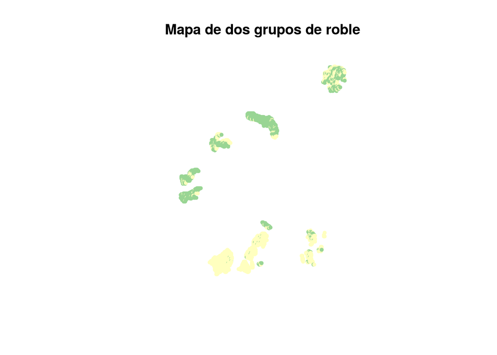

```r
# Creamos el plot, asignando el color en función del cluster al que pertenece
plot(robles_cluster2, col=plotclr2[robles_cluster2$n_cluster2], pch=19, cex = .6, main = "Mapa de dos grupos de roble")
```

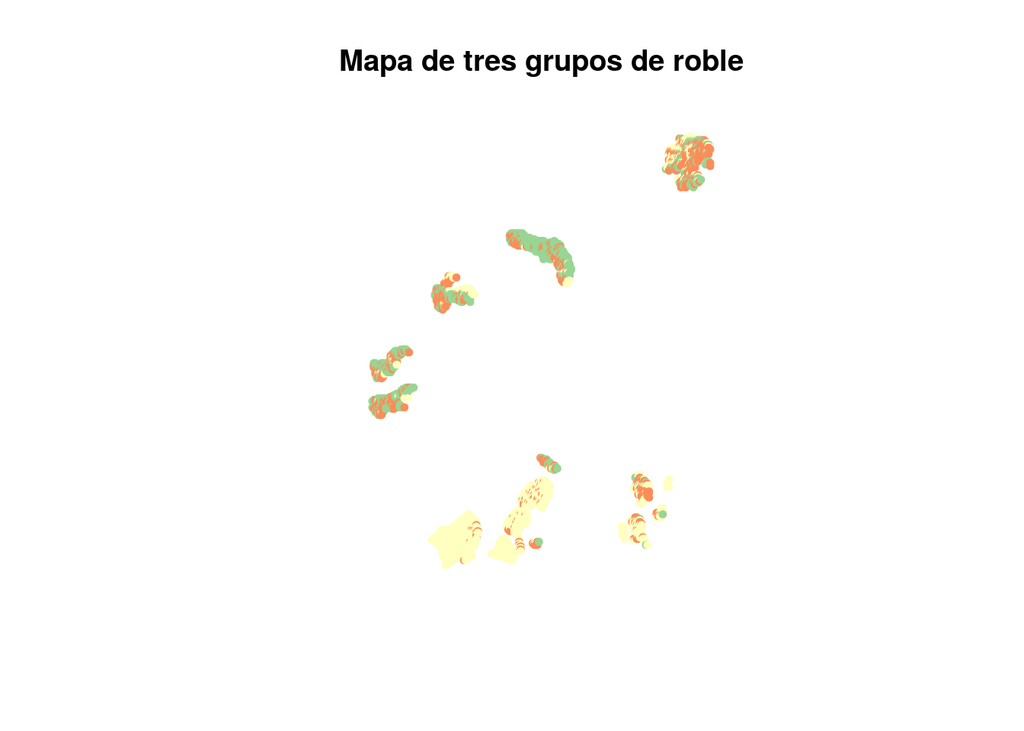

```r
plot(robles_cluster3, col=plotclr3[robles_cluster3$n_cluster3], pch=19, cex = .6, main = "Mapa de tres grupos de roble")
```

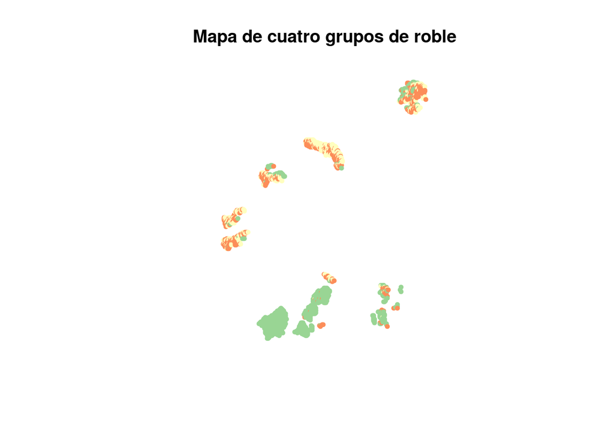

```r
plot(robles_cluster4, col=plotclr4[robles_cluster4$n_cluster4], pch=19, cex = .6, main = "Mapa de cuatro grupos de roble")
```

Hemos obtenido distintos mapas para cada uno de los grupos, 2,3 y 4. En los resultados de **dos** grupos cluster de robledales, observamos una clara diferenciación entre las poblaciones de robledal de la ladera norte y de la ladera sur según las variables biofísicas que le afectan. Una variable de que afecta pues con gran evidencia es la orientación norte o sur de la ladera, ya que es conocido que los robledales necesitan unas condiciones de humedad mínimas durante el periodo vegetativo (Martinez-Parras & Molero, 1982) y en Sierra Nevada los robledales, que se corresponden con su límite mas meridional de distribución, consiguen este aporte situándose en lugares donde las condiciones microclimáticas les permitan conseguir este aporte hídrico.

Al agrupar las poblaciones en **tres** zonas diferentes según las variables biofísicas observamos que la discriminación entre las diferentes poblaciones de Sierra Nevada nos ha aportado una diferenciación en tres grupos de poblaciones: dos situados en la zona norte (uno hacia el nordeste y otro más hacia el norte-noroeste) y otro situado al sur. En los del sur existen algunas zonas de robledal que responden de forma similar a los del norte, pero estos constituyen una minoría. Por tanto, en términos generales sí que podemos hacer dicha distinción en tres poblaciones. La agrupación en **cuatro** clases es muy similar a la de tres, existiendo una ausencia de un cambio significativo al aumentar el número de clasificación, es por ello por lo que decidimos no continuar agrupando en un número mayor de grupos y la razón por la que nos quedamos con tres, pues parece el resultado más apropiado para trabajar con grupos funcionales de robles. Decidimos quedarnos con la clasificación de tres grupos funcionales, debido a que existen diferencias respecto a la clasificación de dos grupos, mientras que no existen diferencias con el de cuatro.

Un procedimiento que podríamos realizar con datos obtenidos, sería establecer relaciones entre la variables y los tipos de cluster mediante gráficos, por ejemplo:

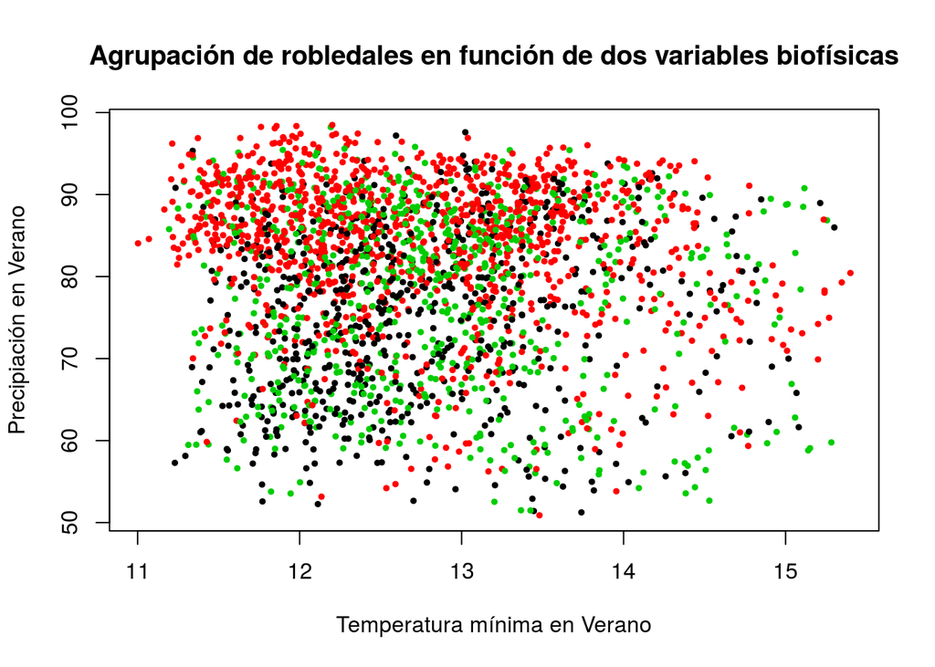

```r
## Gráfico que  muestra la distribución de los grupos de cluster en relación con las variables
plot(robles_cluster3$P_ver~robles_cluster3$tminV, col=as.numeric(robles_cluster3$n_cluster3), pch=19, cex=.5, xlab="Temperatura mínima en Verano", ylab="Precipiación en Verano", main= "Agrupación de robledales en función de dos variables biofísicas")
```

# **Discusión y conclusiones**

Tanto la clasificación en dos grupos como en tres de respuesta a factores ambientales de las poblaciones de roble nos sería válida. La primera aproximación sería más general, y por tanto podría servirnos, pero para la gestión los resultados más exahustivos posibles, por lo tanto conviene decantarnos por la clasificación de tres poblaciones con distintas respuestas.

Podemos concluir que, este tipo de producto, sirve como análisis preliminar que permite optimizar esfuerzos a la hora de realizar estudios específicos sobre diferentes aspectos relacionados con el cambio global, ya que identifica los diferentes grupos de poblaciones de un ecosistema sensible y de alta fragilidad como son los robledales, en una región montañosa, lugares de alerta temprana de los efectos del cambio global.

Por tanto, hemos de destacar que esta clasificación aporta conocimiento científico para la gestión, conservación y restauración de los robledales.

# **Bibliografía**

Alcaraz-Segura, D.; Paruelo, J. & Cabello, J.(2006). Identification of current ecosystem functional types in the Iberian Peninsula. Global Ecology and Biogeography, Vol.15, No.2, pp. 200-212,

Baraza, E., Gómez, J.M., Hódar, J.A. & Zamora, R. (2004) Herbivory has a greater impact in shade than insun : response of Quercus pyrenaica seedlings to multifactorial environmental variation. Canadian Journal of Botany, Vol. 364, 357-364.

Baraza, E., Zamora, R. & Hódar, J.A. (2010) Species-specific responses of tree saplings to herbivory in contrasting lighte environments: an experimental approach. Ecoscience, Vol. 17, 156-165.

Castro, J., Zamora, R. & Hódar, J.A. (2006). Restoring Quercus pyrenaica forests using pioneer shrubs as nurse plants. Applied Vegetation Science, Vol.9, 137-142.

Fernández, N., Paruelo, J. M., & Delibes, M. (2010). Ecosystem functioning of protected and altered Mediterranean environments: A remote sensing classification in Doñana, Spain. Remote Sensing of Environment, Vol.114,No.1, 211-220.

Gómez-Aparicio, L., Valladares, F., Zamora, R. & Quero, J.L. (2005). Response of tree seedlings to the abiotic heterogeneity generated by nurse shrubs: an experimental approach at different scales. Ecography, Vol.28, 757-768.

Martínez-Parras, J.M. & Molero, J. (1982) Ecología y fitososociología de Quercus pyrenaica. Willd. en la provincia Bética. Los melojares béticos y sus etapas de sustitución. Lazaroa, Vol.4, 91-104.

Mendoza, I., Zamora, R. & Castro, J. (2009). A seeding experiment for testing tree-community recruitment under variable environments: Implications for forest regeneration and conservation in Mediterranean habitats. Biological Conservation, Vol.142, 1491-1499.

Tibshirani, R., Walther, G., & Hastie, T. (2001). Estimating the number of clusters in a data set via the gap statistic. Journal of the Royal Statistical Society Series B-Statistical Methodology, Vol.63, 411−423.